# Introduction to PXDataset2 object

Mohieddin Jafari

2025-05-04 15:58:34

## Resources

Bioconductor packages tagged by “proteomics”: https://bioconductor.org/packages/release/BiocViews.html#___Proteomics

```r
knitr::opts_chunk$set(echo = FALSE)
## install.package("BiocManager")

#library(BiocManager)

# Bioconductor packages
# if (!requireNamespace("BiocManager", quietly = TRUE))
#     install.packages("BiocManager")
#
# BiocManager::install("tidyverse")
# BiocManager::install("factoextra")
# BiocManager::install("msdata")
# BiocManager::install("mzR")
# BiocManager::install("rhdf5")
# BiocManager::install("rpx")
# BiocManager::install("MsCoreUtils")
# BiocManager::install("QFeatures")
# BiocManager::install("Spectra")
# BiocManager::install("ProtGenerics")
# BiocManager::install("PSMatch")
# BiocManager::install("pheatmap")
# BiocManager::install("limma")
# BiocManager::install("MSnID")
# BiocManager::install("RforMassSpectrometry/SpectraVis")
#
# install.packages("tidyverse")
```

## Review some points about MS data

- The continuous workflow of separating-separating-separating!
- Three dimensions: Retention time of analyser elution - M/Z - Measurement of Intensity

**Spectrum is the unit of mass spectrometry data**

*TIC (total ion chromatogram) plot*: The intensities of all ions in each mass spectrometer scan (within a given time period) are summed and plotted as a function of time. *Base peak chromatogram plot*: The intensity of the base peak (the most intense ion in each mass spectrum) is plotted as a function of time. (Note: do not confuse the base peak with the baseline, which represents the constant signal from the background level of the instrument.) *XIC or EIC plot*: The intensity of a specific analyte at a chosen m/z value (either total or base peak intensity) is isolated and plotted as a function of time.

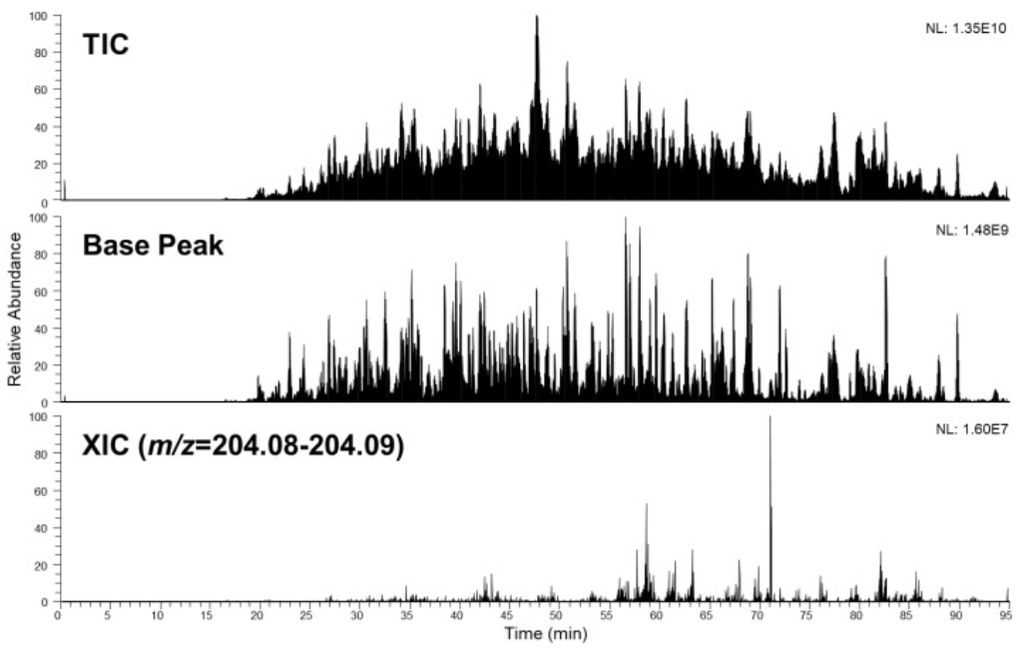

## Getting data

Get to know the ProteomeXchange Consortium: Established to create globally coordinated, standardized pipelines for data submission and dissemination across major proteomics repositories, the Consortium promotes open data policies in proteomics.

`proteomexchange.org`

```r
#Direct accessing data
library("rpx")
px <- PXDataset("PXD022816")
pxget(px, grep("mzID", pxfiles(px))[1:3])
```

```
## [1] "/Users/mohi/Library/Caches/org.R-project.R/R/rpx/181fc3671c09f_QEP2LC6_HeLa_50ng_251120_01-calib.mzID.gz"
## [2] "/Users/mohi/Library/Caches/org.R-project.R/R/rpx/181fc661d22a5_QEP2LC6_HeLa_50ng_251120_02-calib.mzID.gz"
## [3] "/Users/mohi/Library/Caches/org.R-project.R/R/rpx/181fc2cdb303_QEP2LC6_HeLa_50ng_251120_03-calib.mzID.gz"
```

```r
pxget(px, grep("mzML", pxfiles(px))[1:3])
```

```
## [1] "/Users/mohi/Library/Caches/org.R-project.R/R/rpx/181fc6adec32b_QEP2LC6_HeLa_50ng_251120_01-calib.mzML"
## [2] "/Users/mohi/Library/Caches/org.R-project.R/R/rpx/181fc46df72dd_QEP2LC6_HeLa_50ng_251120_02-calib.mzML"
## [3] "/Users/mohi/Library/Caches/org.R-project.R/R/rpx/181fc77ee2f84_QEP2LC6_HeLa_50ng_251120_03-calib.mzML"
```

```r
px <- PXDataset("PXD000001")
#PXDataset("PXD000294")
px
```

```
## Project PXD000001 with 11 files
##
```

```
##  [1] 'F063721.dat' ... [11] 'erwinia_carotovora.fasta'
##  Use 'pxfiles(.)' to see all files.
```

```r
fn <- "TMT_Erwinia_1uLSike_Top10HCD_isol2_45stepped_60min_01-20141210.mzML"
mzf <- pxget(px, fn)

pxtax(px) # taxonomic name
```

```
## [1] "Erwinia carotovora"
```

```r
pxref(px) # bibliography ref
```

```
## [1] "Gatto L, Christoforou A; Using R and Bioconductor for proteomics data analysis., Biochim Biophys Acta, 2013 May 18, doi:10.1016/j.bbapap.2013.04.032 PMID:23692960"
```

```r
pxfiles(px) # file names of the object
pxfiles(px, as.vector = TRUE) |> print()
```

```
##  [1] "F063721.dat"
##  [2] "F063721.dat-mztab.txt"
##  [3] "PRIDE_Exp_Complete_Ac_22134.xml.gz"
##  [4] "PRIDE_Exp_mzData_Ac_22134.xml.gz"
##  [5] "PXD000001_mztab.txt"
##  [6] "README.txt"
##  [7] "TMT_Erwinia_1uLSike_Top10HCD_isol2_45stepped_60min_01-20141210.mzML"
##  [8] "TMT_Erwinia_1uLSike_Top10HCD_isol2_45stepped_60min_01-20141210.mzXML"
##  [9] "TMT_Erwinia_1uLSike_Top10HCD_isol2_45stepped_60min_01.mzXML"
## [10] "TMT_Erwinia_1uLSike_Top10HCD_isol2_45stepped_60min_01.raw"
## [11] "erwinia_carotovora.fasta"
```

```r
pxget(px, "erwinia_carotovora.fasta")
```

```
## [1] "/Users/mohi/Library/Caches/org.R-project.R/R/rpx/66c828118fa2_erwinia_carotovora.fasta"
```

```r
pxget(px, "README.txt") # a vector defining the files to be downloaded
```

```
## [1] "/Users/mohi/Library/Caches/org.R-project.R/R/rpx/f4984c082279_README.txt"
```

```r
# Some files are accessible remotly and some of them from local cashing mechanism.
(f <- pxget(px, "TMT_Erwinia_1uLSike_Top10HCD_isol2_45stepped_60min_01-20141210.mzML"))
```

```
## [1] "/Users/mohi/Library/Caches/org.R-project.R/R/rpx/f4982a0f5cee_TMT_Erwinia_1uLSike_Top10HCD_isol2_45stepped_60min_01-20141210.mzML"
```

```r
basename(f)
```

```
## [1] "f4982a0f5cee_TMT_Erwinia_1uLSike_Top10HCD_isol2_45stepped_60min_01-20141210.mzML"
```

## MS example data: msdata

```r
# Various Mass Spectrometry raw data example files for proteomics and metabolomics
library(msdata)
proteomics()
```

```
## [1] "MRM-standmix-5.mzML.gz"
## [2] "MS3TMT10_01022016_32917-33481.mzML.gz"
## [3] "MS3TMT11.mzML"
## [4] "TMT_Erwinia_1uLSike_Top10HCD_isol2_45stepped_60min_01-20141210.mzML.gz"
## [5] "TMT_Erwinia_1uLSike_Top10HCD_isol2_45stepped_60min_01.mzML.gz"
```

```r
ident()
```

```
## [1] "TMT_Erwinia_1uLSike_Top10HCD_isol2_45stepped_60min_01-20141210.mzid"
```

```r
quant()
```

```
## [1] "cptac_a_b_peptides.txt"
```

### Quiz 1 (GA_4)

Visit `gosocrative.com` and enter room name `FIN2025`

## Raw MS data

- We need to convert binary-vendor-specific formats to open formats such as mzML, mzXML.
- mzML is the most recent format.
- proteowizard msconvert: https://proteowizard.sourceforge.io/ or search in Google msconvert GUI
- ThermoRawFileParser: https://github.com/compomics/ThermoRawFileParser
- To check all MS-related data format: https://en.wikipedia.org/wiki/Mass_spectrometry_data_format

## MS data from R prospective

https://rformassspectrometry.github.io/book/img/F02-3D-MS1-MS2-scans-100-1200-lattice.png —->>>> https://rformassspectrometry.github.io/book/img/raw.png